# Reproducible data reports with Quarto

Theo Roe

## Welcome

Wifi details

vm details

# Me

## Schedule

- 1:30 - 3 workshop pt 1
- 3 - 3:30 refreshment break
- 3:30 - 5 workshop pt 2
- 5 - 7 drinks reception

# Quarto

## What?

- Tool created by RStudio
- Let’s us write documents that combine code with text
- Multiple language and multiple output formats
- Effectively a “version 2” of R Markdown
- File extension `.qmd`

## What?

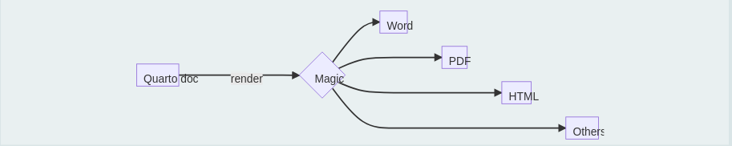

## Where?

- https://quarto.org/docs/get-started/

## Why?

- R Markdown isn’t going anywhere
- So why should we be using Quarto instead?

## Why?

Vs R Markdown:

- Quarto is **not** an R package
- Publishing system built on Pandoc

## Why?

Vs R Markdown:

- Better multi-language support
  - Use Python, Julia and Observable JS without having to have R installed (!!!!!!)
- Can be used in:
  - RStudio
  - VS Code
  - Jupyter Notebookes
  - Text editors / terminal

## Why?

Vs R Markdown:

- IMO better documentation
- More user friendly
- Better control of the output layouts
- Can still render most R Markdown files without modification

# The plan

## Part 1

- Look at Quarto basics:
  - Creating a document
  - Document parameters
  - Including code
  - Including tables, plots

## Part 2

- Walk through a few different outputs in quarto

## The plan

- At the end you’ll have an example of a
  - HTML document
  - presentation
  - dashboard (ish)
- You’ll be able to download all of these

[figure not shown]